# **SPACESHIP TITANIC🚀 ~ 0.81 % XGBoost - EDA + PREPROCESSING + ML**

train.csv - Personal records for about two-thirds (~8700) of the passengers, to be used as training data.

1. PassengerId - A unique Id for each passenger. Each Id takes the form gggg_pp where gggg indicates a group the passenger is travelling with and pp is their number within the group. People in a group are often family members, but not always.
2. HomePlanet - The planet the passenger departed from, typically their planet of permanent residence.
3. CryoSleep - Indicates whether the passenger elected to be put into suspended animation for the duration of the voyage. Passengers in cryosleep are confined to their cabins.
4. Cabin - The cabin number where the passenger is staying. Takes the form deck/num/side, where side can be either P for Port or S for Starboard.
5. Destination - The planet the passenger will be debarking to.
6. Age - The age of the passenger.
7. VIP - Whether the passenger has paid for special VIP service during the voyage.
8. RoomService, FoodCourt, ShoppingMall, Spa, VRDeck - Amount the passenger has billed at each of the Spaceship Titanic's many luxury amenities.
9. Name - The first and last names of the passenger.
10. Transported - Whether the passenger was transported to another dimension. This is the target, the column you are trying to predict.

# Import Libraries

```python
import numpy as np
import pandas as pd
import seaborn as sns
import matplotlib.pyplot as plt
import warnings
from sklearn.preprocessing import StandardScaler,LabelEncoder
from scipy import stats
warnings.filterwarnings('ignore')
```

# Load Dataset

```python
train = pd.read_csv('/kaggle/input/spaceship-titanic/train.csv')
test = pd.read_csv('/kaggle/input/spaceship-titanic/test.csv')
```

```python
train.head()
```

|  | PassengerId | HomePlanet | CryoSleep | Cabin | Destination | Age | VIP | RoomService | FoodCourt | ShoppingMall | Spa | VRDeck | Name | Transported |
| --- | --- | --- | --- | --- | --- | --- | --- | --- | --- | --- | --- | --- | --- | --- |
| 0 | 0001_01 | Europa | False | B/0/P | TRAPPIST-1e | 39.0 | False | 0.0 | 0.0 | 0.0 | 0.0 | 0.0 | Maham Ofracculy | False |
| 1 | 0002_01 | Earth | False | F/0/S | TRAPPIST-1e | 24.0 | False | 109.0 | 9.0 | 25.0 | 549.0 | 44.0 | Juanna Vines | True |
| 2 | 0003_01 | Europa | False | A/0/S | TRAPPIST-1e | 58.0 | True | 43.0 | 3576.0 | 0.0 | 6715.0 | 49.0 | Altark Susent | False |
| 3 | 0003_02 | Europa | False | A/0/S | TRAPPIST-1e | 33.0 | False | 0.0 | 1283.0 | 371.0 | 3329.0 | 193.0 | Solam Susent | False |
| 4 | 0004_01 | Earth | False | F/1/S | TRAPPIST-1e | 16.0 | False | 303.0 | 70.0 | 151.0 | 565.0 | 2.0 | Willy Santantines | True |

```python
test.head()
```

|  | PassengerId | HomePlanet | CryoSleep | Cabin | Destination | Age | VIP | RoomService | FoodCourt | ShoppingMall | Spa | VRDeck | Name |
| --- | --- | --- | --- | --- | --- | --- | --- | --- | --- | --- | --- | --- | --- |
| 0 | 0013_01 | Earth | True | G/3/S | TRAPPIST-1e | 27.0 | False | 0.0 | 0.0 | 0.0 | 0.0 | 0.0 | Nelly Carsoning |
| 1 | 0018_01 | Earth | False | F/4/S | TRAPPIST-1e | 19.0 | False | 0.0 | 9.0 | 0.0 | 2823.0 | 0.0 | Lerome Peckers |
| 2 | 0019_01 | Europa | True | C/0/S | 55 Cancri e | 31.0 | False | 0.0 | 0.0 | 0.0 | 0.0 | 0.0 | Sabih Unhearfus |
| 3 | 0021_01 | Europa | False | C/1/S | TRAPPIST-1e | 38.0 | False | 0.0 | 6652.0 | 0.0 | 181.0 | 585.0 | Meratz Caltilter |
| 4 | 0023_01 | Earth | False | F/5/S | TRAPPIST-1e | 20.0 | False | 10.0 | 0.0 | 635.0 | 0.0 | 0.0 | Brence Harperez |

```python
train.info()
```

```
<class 'pandas.core.frame.DataFrame'>
RangeIndex: 8693 entries, 0 to 8692
Data columns (total 14 columns):
 #   Column        Non-Null Count  Dtype
---  ------        --------------  -----
 0   PassengerId   8693 non-null   object
 1   HomePlanet    8492 non-null   object
 2   CryoSleep     8476 non-null   object
 3   Cabin         8494 non-null   object
 4   Destination   8511 non-null   object
 5   Age           8514 non-null   float64
 6   VIP           8490 non-null   object
 7   RoomService   8512 non-null   float64
 8   FoodCourt     8510 non-null   float64
 9   ShoppingMall  8485 non-null   float64
 10  Spa           8510 non-null   float64
 11  VRDeck        8505 non-null   float64
 12  Name          8493 non-null   object
 13  Transported   8693 non-null   bool
dtypes: bool(1), float64(6), object(7)
memory usage: 891.5+ KB
```

```python
test.info()
```

```
<class 'pandas.core.frame.DataFrame'>
RangeIndex: 4277 entries, 0 to 4276
Data columns (total 13 columns):
 #   Column        Non-Null Count  Dtype
---  ------        --------------  -----
 0   PassengerId   4277 non-null   object
 1   HomePlanet    4190 non-null   object
 2   CryoSleep     4184 non-null   object
 3   Cabin         4177 non-null   object
 4   Destination   4185 non-null   object
 5   Age           4186 non-null   float64
 6   VIP           4184 non-null   object
 7   RoomService   4195 non-null   float64
 8   FoodCourt     4171 non-null   float64
 9   ShoppingMall  4179 non-null   float64
 10  Spa           4176 non-null   float64
 11  VRDeck        4197 non-null   float64
 12  Name          4183 non-null   object
dtypes: float64(6), object(7)
memory usage: 434.5+ KB
```

```python
train.describe().T
```

|  | count | mean | std | min | 25% | 50% | 75% | max |
| --- | --- | --- | --- | --- | --- | --- | --- | --- |
| Age | 8514.0 | 28.827930 | 14.489021 | 0.0 | 19.0 | 27.0 | 38.0 | 79.0 |
| RoomService | 8512.0 | 224.687617 | 666.717663 | 0.0 | 0.0 | 0.0 | 47.0 | 14327.0 |
| FoodCourt | 8510.0 | 458.077203 | 1611.489240 | 0.0 | 0.0 | 0.0 | 76.0 | 29813.0 |
| ShoppingMall | 8485.0 | 173.729169 | 604.696458 | 0.0 | 0.0 | 0.0 | 27.0 | 23492.0 |
| Spa | 8510.0 | 311.138778 | 1136.705535 | 0.0 | 0.0 | 0.0 | 59.0 | 22408.0 |
| VRDeck | 8505.0 | 304.854791 | 1145.717189 | 0.0 | 0.0 | 0.0 | 46.0 | 24133.0 |

```python
test.describe().T
```

|  | count | mean | std | min | 25% | 50% | 75% | max |
| --- | --- | --- | --- | --- | --- | --- | --- | --- |
| Age | 4186.0 | 28.658146 | 14.179072 | 0.0 | 19.0 | 26.0 | 37.0 | 79.0 |
| RoomService | 4195.0 | 219.266269 | 607.011289 | 0.0 | 0.0 | 0.0 | 53.0 | 11567.0 |
| FoodCourt | 4171.0 | 439.484296 | 1527.663045 | 0.0 | 0.0 | 0.0 | 78.0 | 25273.0 |
| ShoppingMall | 4179.0 | 177.295525 | 560.821123 | 0.0 | 0.0 | 0.0 | 33.0 | 8292.0 |
| Spa | 4176.0 | 303.052443 | 1117.186015 | 0.0 | 0.0 | 0.0 | 50.0 | 19844.0 |
| VRDeck | 4197.0 | 310.710031 | 1246.994742 | 0.0 | 0.0 | 0.0 | 36.0 | 22272.0 |

```python
counts = train[train.columns].isnull().sum()
perc = round(counts / train.shape[0] * 100,2)

train_null = pd.DataFrame({'counts' : counts, 'percentage' : perc})
train_null
```

|  | counts | percentage |
| --- | --- | --- |
| PassengerId | 0 | 0.00 |
| HomePlanet | 201 | 2.31 |
| CryoSleep | 217 | 2.50 |
| Cabin | 199 | 2.29 |
| Destination | 182 | 2.09 |
| Age | 179 | 2.06 |
| VIP | 203 | 2.34 |
| RoomService | 181 | 2.08 |
| FoodCourt | 183 | 2.11 |
| ShoppingMall | 208 | 2.39 |
| Spa | 183 | 2.11 |
| VRDeck | 188 | 2.16 |
| Name | 200 | 2.30 |
| Transported | 0 | 0.00 |

```python
counts = test[test.columns].isnull().sum()
perc = round(counts / test.shape[0] * 100,2)

test_null = pd.DataFrame({'counts' : counts, 'percentage' : perc})
test_null
```

|  | counts | percentage |
| --- | --- | --- |
| PassengerId | 0 | 0.00 |
| HomePlanet | 87 | 2.03 |
| CryoSleep | 93 | 2.17 |
| Cabin | 100 | 2.34 |
| Destination | 92 | 2.15 |
| Age | 91 | 2.13 |
| VIP | 93 | 2.17 |
| RoomService | 82 | 1.92 |
| FoodCourt | 106 | 2.48 |
| ShoppingMall | 98 | 2.29 |
| Spa | 101 | 2.36 |
| VRDeck | 80 | 1.87 |
| Name | 94 | 2.20 |

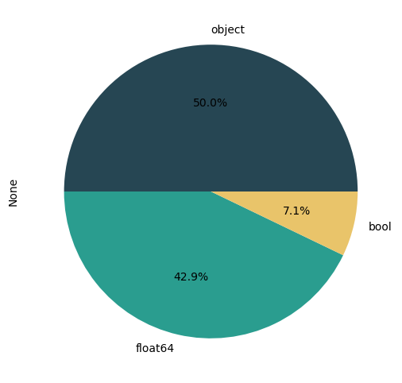

```python
plt.figure(figsize=(8,6))
train.dtypes.value_counts().plot(kind='pie',autopct='%.1f%%',colors=['#264653', '#2a9d8f','#e9c46a'])
plt.show()
```

# EDA

## Statistical Descriptive

```python
dtrain = train.copy()
```

```python
dtrain['Transported'].value_counts()
```

```
True     4378
False    4315
Name: Transported, dtype: int64
```

```python
cat = ['HomePlanet', 'CryoSleep', 'Destination', 'VIP']
num = ['Age', 'RoomService', 'FoodCourt', 'ShoppingMall', 'Spa', 'VRDeck']
```

```python
dtrain[num].describe().T
```

|  | count | mean | std | min | 25% | 50% | 75% | max |
| --- | --- | --- | --- | --- | --- | --- | --- | --- |
| Age | 8514.0 | 28.827930 | 14.489021 | 0.0 | 19.0 | 27.0 | 38.0 | 79.0 |
| RoomService | 8512.0 | 224.687617 | 666.717663 | 0.0 | 0.0 | 0.0 | 47.0 | 14327.0 |
| FoodCourt | 8510.0 | 458.077203 | 1611.489240 | 0.0 | 0.0 | 0.0 | 76.0 | 29813.0 |
| ShoppingMall | 8485.0 | 173.729169 | 604.696458 | 0.0 | 0.0 | 0.0 | 27.0 | 23492.0 |
| Spa | 8510.0 | 311.138778 | 1136.705535 | 0.0 | 0.0 | 0.0 | 59.0 | 22408.0 |
| VRDeck | 8505.0 | 304.854791 | 1145.717189 | 0.0 | 0.0 | 0.0 | 46.0 | 24133.0 |

```python
dtrain[cat].describe().T
```

|  | count | unique | top | freq |
| --- | --- | --- | --- | --- |
| HomePlanet | 8492 | 3 | Earth | 4602 |
| CryoSleep | 8476 | 2 | False | 5439 |
| Destination | 8511 | 3 | TRAPPIST-1e | 5915 |
| VIP | 8490 | 2 | False | 8291 |

```python
d={}

for i in dtrain.columns:
    d[i] = pd.concat([dtrain.groupby(i).Transported.sum(),dtrain[i].value_counts(),round(dtrain.groupby(i).Transported.sum()*100/dtrain[i].value_counts(),2)], axis=1)
    d[i].reset_index(level=0,inplace=True)
    d[i] = d[i].rename(columns = {'index':i, 'Transported':'People_Transported', i:'Total_People', 0:'perc_of_total_people'}, )
```

```python
for i in dtrain.columns:
    print(i)
    print(d[i])
    print()
```

```
PassengerId
     PassengerId  People_Transported  Total_People  perc_of_total_people
0        0001_01                   0             1                   0.0
1        0002_01                   1             1                 100.0
2        0003_01                   0             1                   0.0
3        0003_02                   0             1                   0.0
4        0004_01                   1             1                 100.0
...          ...                 ...           ...                   ...
8688     9276_01                   0             1                   0.0
8689     9278_01                   0             1                   0.0
8690     9279_01                   1             1                 100.0
8691     9280_01                   0             1                   0.0
8692     9280_02                   1             1                 100.0

[8693 rows x 4 columns]

HomePlanet
  HomePlanet  People_Transported  Total_People  perc_of_total_people
0      Earth                1951          4602                 42.39
1     Europa                1404          2131                 65.88
2       Mars                 920          1759                 52.30

CryoSleep
   CryoSleep  People_Transported  Total_People  perc_of_total_people
0      False                1789          5439                 32.89
1       True                2483          3037                 81.76

Cabin
       Cabin  People_Transported  Total_People  perc_of_total_people
0      A/0/P                   1             2                  50.0
1      A/0/S                   0             2                   0.0
2      A/1/S                   3             3                 100.0
3     A/10/P                   0             1                   0.0
4     A/10/S                   1             1                 100.0
...      ...                 ...           ...                   ...
6555   T/0/P                   0             1                   0.0
6556   T/1/P                   0             1                   0.0
6557   T/2/P                   0             1                   0.0
6558   T/2/S                   0             1                   0.0
6559   T/3/P                   1             1                 100.0
```

[output cut: 128 more lines]

```
3                      0.0
4                    100.0
...                    ...
8468                 100.0
8469                 100.0
8470                 100.0
8471                 100.0
8472                   0.0

[8473 rows x 4 columns]

Transported
   Transported  Total_People  Total_People  Total_People
0        False             0          4315           0.0
1         True          4378          4378         100.0
```

## Univariate Analysis

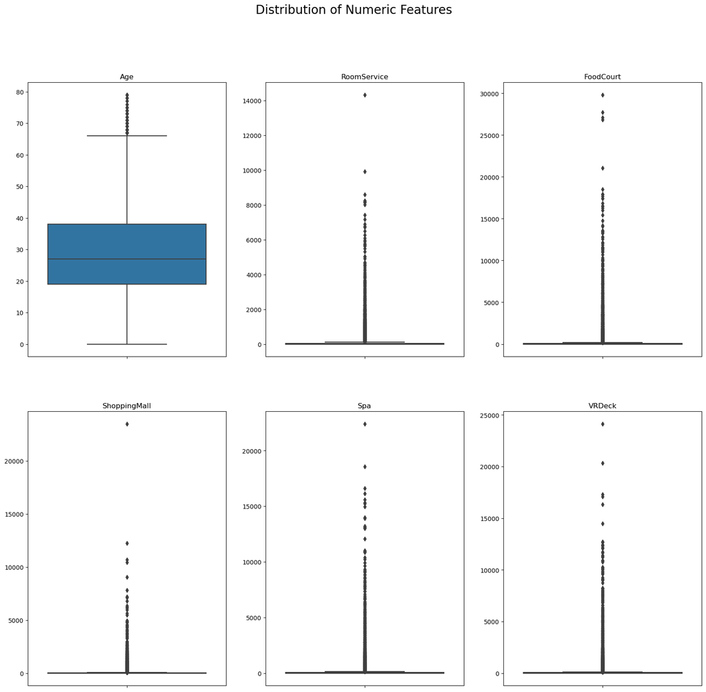

```python
fig, ax = plt.subplots(2,3,figsize=(20, 18))
fig.suptitle('Distribution of Numeric Features', fontsize=20)
ax = ax.flatten()
for i,c in enumerate(num):
    sns.boxplot(y=c, data=dtrain, ax=ax[i])
    ax[i].set_title(c)
    ax[i].set_ylabel('')
plt.show()
```

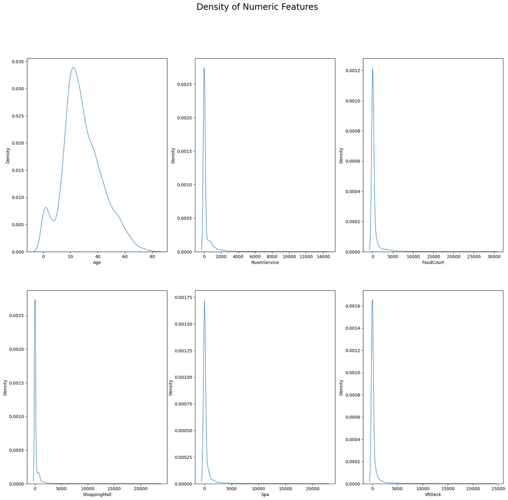

```python
fig, ax = plt.subplots(2,3,figsize=(20, 18))
fig.suptitle('Density of Numeric Features', fontsize=20)
ax = ax.flatten()

for i,c in enumerate(num):
  sns.kdeplot(dtrain[c], linewidth= 1,ax=ax[i])

plt.show()
```

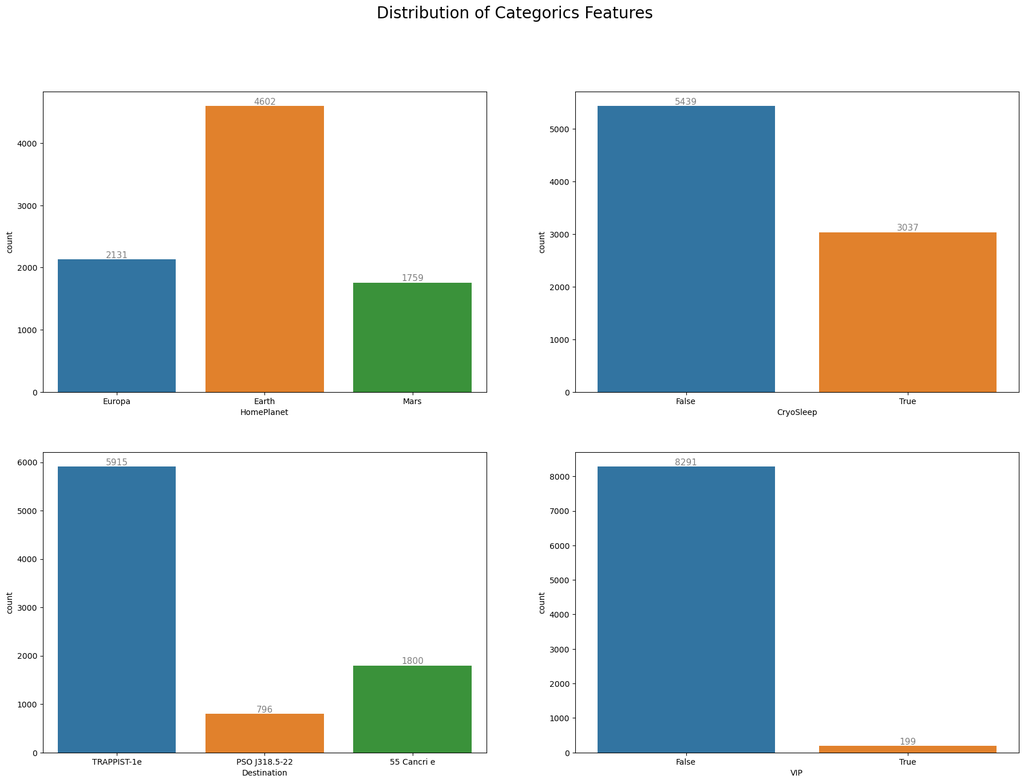

```python
fig, ax = plt.subplots(2,2,figsize=(22, 15))
fig.suptitle('Distribution of Categorics Features', fontsize=20)
ax = ax.flatten()
for i,c in enumerate(cat):
    sns.countplot(x=c, data=dtrain, ax=ax[i])
    plt.xlabel(c)
    for p in ax[i].patches:
        ax[i].annotate('{:.0f}'.format(p.get_height()), (p.get_x() + p.get_width()/2., p.get_height()), ha='center', va='center', fontsize=11, color='gray', xytext=(0, 5), textcoords='offset points')
plt.show()
```

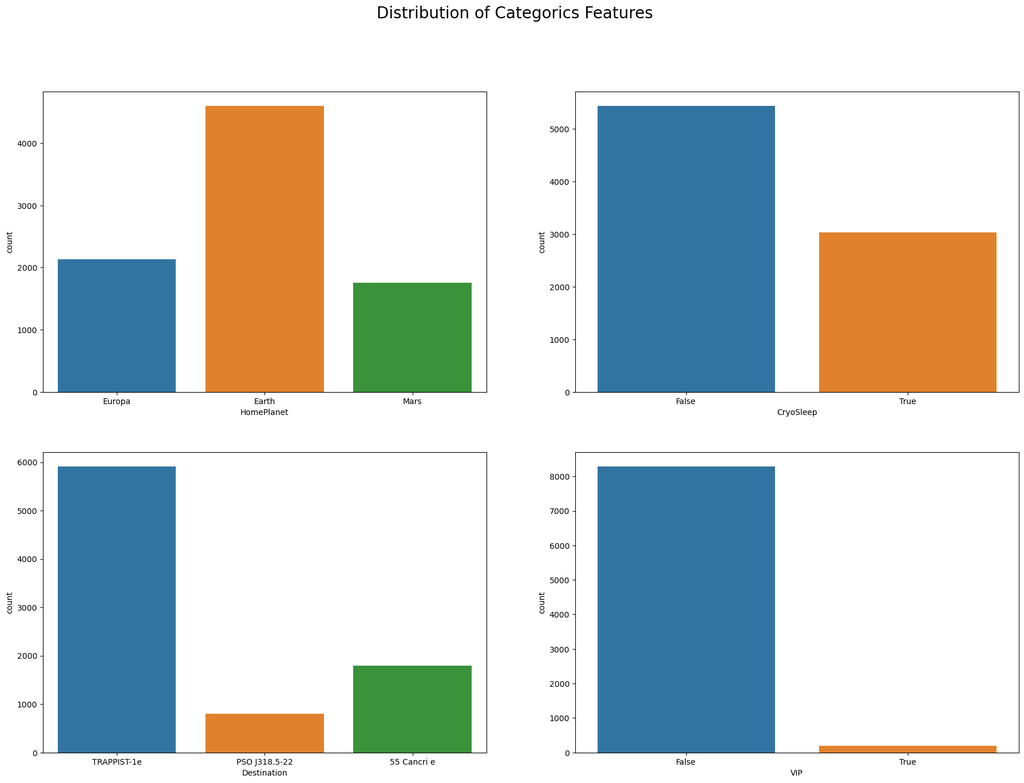

```python
fig, ax = plt.subplots(2,2,figsize=(22, 15))
fig.suptitle('Distribution of Categorics Features', fontsize=20)
ax = ax.flatten()
for i,c in enumerate(cat):
  sns.countplot(x= c, data=dtrain, ax=ax[i])
  plt.xlabel(c);
plt.show()
```

## Bivariate Analysis

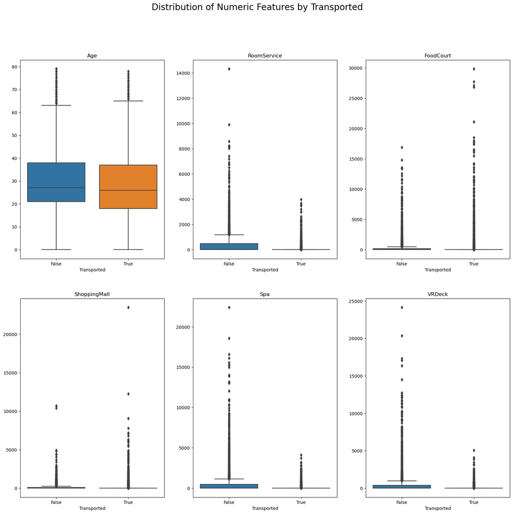

```python
fig, ax = plt.subplots(2,3,figsize=(20, 18))
fig.suptitle('Distribution of Numeric Features by Transported', fontsize=20)
ax = ax.flatten()
for i,c in enumerate(num):
  sns.boxplot(x='Transported', y=c, data=dtrain, ax=ax[i])
  ax[i].set_title(c)
  ax[i].set_ylabel('')
plt.show()
```

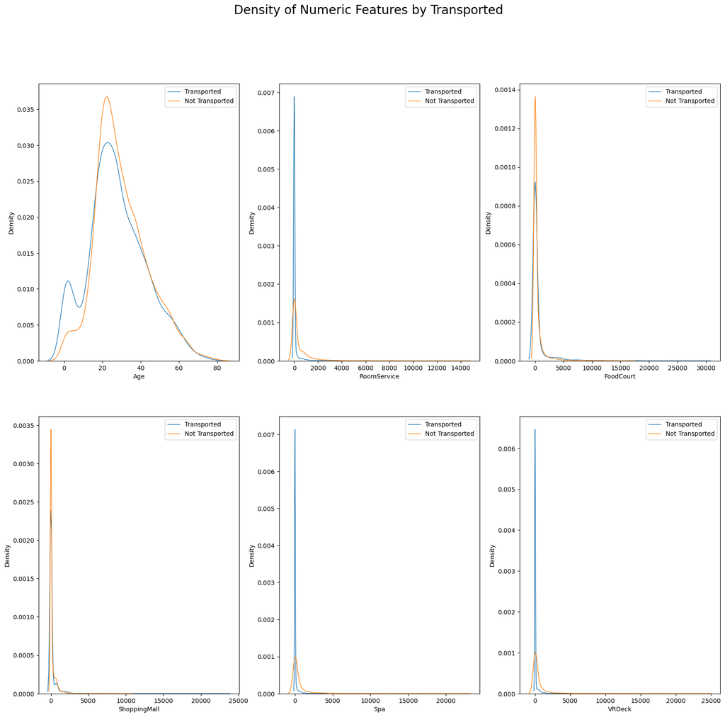

```python
dfc = dtrain[dtrain['Transported']==1]
dfn = dtrain[dtrain['Transported']==0]

fig, ax = plt.subplots(2,3,figsize=(20, 18))
fig.suptitle('Density of Numeric Features by Transported', fontsize=20)
ax = ax.flatten()

for i,c in enumerate(num):
  sns.kdeplot(dfc[c], linewidth= 1, label = 'Transported',ax=ax[i])
  sns.kdeplot(dfn[c], linewidth= 1, label = 'Not Transported',ax=ax[i])
  ax[i].legend(loc='upper right')

plt.show()
```

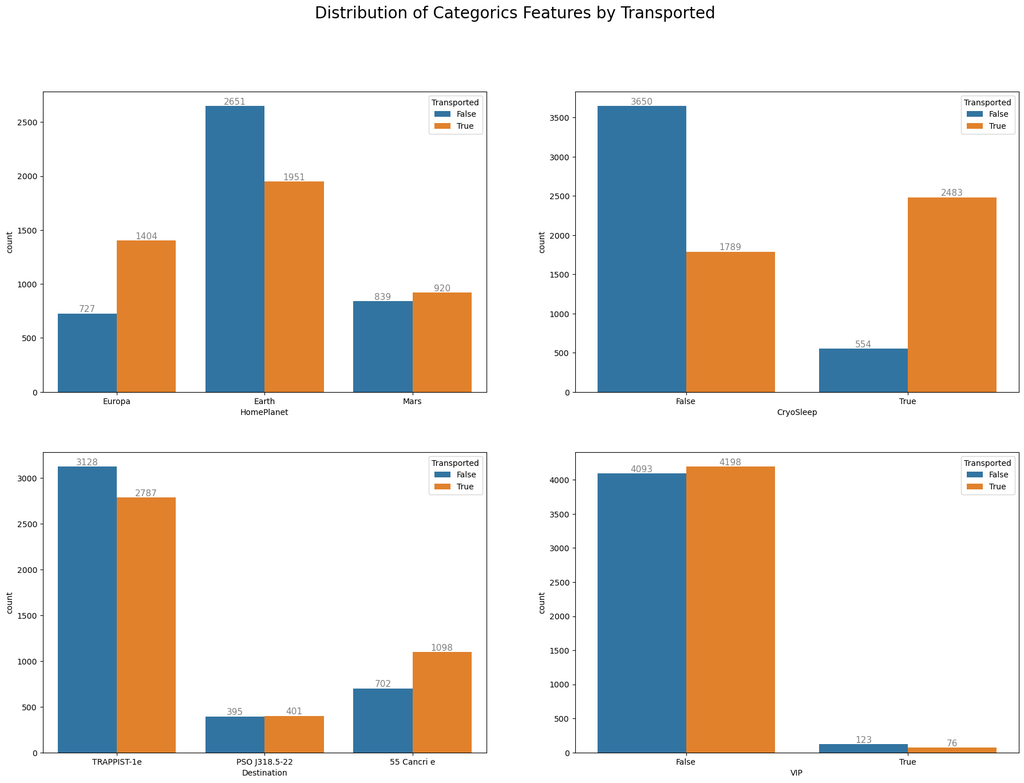

```python
fig, ax = plt.subplots(2,2,figsize=(22, 15))
fig.suptitle('Distribution of Categorics Features by Transported', fontsize=20)
ax = ax.flatten()
for i,c in enumerate(cat):
    sns.countplot(x= c, hue='Transported', data=dtrain, ax=ax[i])
    plt.xlabel(c);
    for p in ax[i].patches:
        ax[i].annotate('{:.0f}'.format(p.get_height()), (p.get_x() + p.get_width()/2., p.get_height()), ha='center', va='center', fontsize=11, color='gray', xytext=(0, 5), textcoords='offset points')
plt.show()
```

## Heatmap Correlation

```python
dtrain.info()
```

```
<class 'pandas.core.frame.DataFrame'>
RangeIndex: 8693 entries, 0 to 8692
Data columns (total 14 columns):
 #   Column        Non-Null Count  Dtype
---  ------        --------------  -----
 0   PassengerId   8693 non-null   object
 1   HomePlanet    8492 non-null   object
 2   CryoSleep     8476 non-null   object
 3   Cabin         8494 non-null   object
 4   Destination   8511 non-null   object
 5   Age           8514 non-null   float64
 6   VIP           8490 non-null   object
 7   RoomService   8512 non-null   float64
 8   FoodCourt     8510 non-null   float64
 9   ShoppingMall  8485 non-null   float64
 10  Spa           8510 non-null   float64
 11  VRDeck        8505 non-null   float64
 12  Name          8493 non-null   object
 13  Transported   8693 non-null   bool
dtypes: bool(1), float64(6), object(7)
memory usage: 891.5+ KB
```

```python
dtrain.corr()
```

|  | Age | RoomService | FoodCourt | ShoppingMall | Spa | VRDeck | Transported |
| --- | --- | --- | --- | --- | --- | --- | --- |
| Age | 1.000000 | 0.068723 | 0.130421 | 0.033133 | 0.123970 | 0.101007 | -0.075026 |
| RoomService | 0.068723 | 1.000000 | -0.015889 | 0.054480 | 0.010080 | -0.019581 | -0.244611 |
| FoodCourt | 0.130421 | -0.015889 | 1.000000 | -0.014228 | 0.221891 | 0.227995 | 0.046566 |
| ShoppingMall | 0.033133 | 0.054480 | -0.014228 | 1.000000 | 0.013879 | -0.007322 | 0.010141 |
| Spa | 0.123970 | 0.010080 | 0.221891 | 0.013879 | 1.000000 | 0.153821 | -0.221131 |
| VRDeck | 0.101007 | -0.019581 | 0.227995 | -0.007322 | 0.153821 | 1.000000 | -0.207075 |
| Transported | -0.075026 | -0.244611 | 0.046566 | 0.010141 | -0.221131 | -0.207075 | 1.000000 |

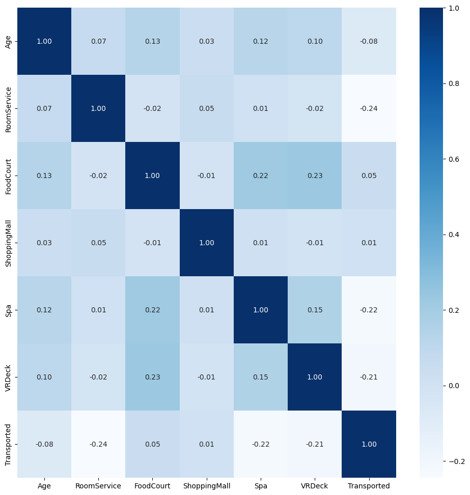

```python
plt.figure(figsize=(12, 12))
sns.heatmap(dtrain.corr(), cmap='Blues', annot=True, fmt='.2f')
```

# Data Preprocessing

```python
dtr = train.copy()
dte = test.copy()
```

## Handling Missing Values

```python
# check missing values in percentage
dtr.isnull().sum()/len(dtr)*100
```

```
PassengerId     0.000000
HomePlanet      2.312205
CryoSleep       2.496261
Cabin           2.289198
Destination     2.093639
Age             2.059128
VIP             2.335212
RoomService     2.082135
FoodCourt       2.105142
ShoppingMall    2.392730
Spa             2.105142
VRDeck          2.162660
Name            2.300702
Transported     0.000000
dtype: float64
```

```python
dtr['PassengerId'].duplicated().sum()
```

```
0
```

```python
def fill_nan(data):
    for c in data.columns:
        if data[c].dtype == 'object':
            data[c] = data[c].fillna(data[c].mode()[0])
        elif data[c].dtype != 'object':
            data[c] = data[c].fillna(data[c].median())

    return data

dtr = fill_nan(dtr)
dte = fill_nan(dte)
```

```python
dtr.isnull().sum()/len(dtr)*100
```

```
PassengerId     0.0
HomePlanet      0.0
CryoSleep       0.0
Cabin           0.0
Destination     0.0
Age             0.0
VIP             0.0
RoomService     0.0
FoodCourt       0.0
ShoppingMall    0.0
Spa             0.0
VRDeck          0.0
Name            0.0
Transported     0.0
dtype: float64
```

## Handling Outliers

```python
import pandas as pd
import numpy as np

# loop through each column in the dataset
for col in dtr.select_dtypes(include=['number']):
    # calculate Z-score for each data point in the column
    z = np.abs((dtr[col] - dtr[col].mean()) / dtr[col].std())

    # check if there are any outliers in the column
    if z.max() > 3:
        print(col, "contains outliers.")
        # Tindakan: bisa melakukan imputasi data untuk mengganti nilai outlier dengan nilai yang masuk akal atau bisa juga menghapus baris yang mengandung nilai outlier.
    else:
        print(col, "does not contain outliers.")
```

```
Age contains outliers.
RoomService contains outliers.
FoodCourt contains outliers.
ShoppingMall contains outliers.
Spa contains outliers.
VRDeck contains outliers.
```

```python
import pandas as pd
import numpy as np

def remove_outliers(df, threshold=3):

    for col in df.select_dtypes(include=['number']):
        # calculate z-score for the column
        zscore = np.abs((df[col] - df[col].mean()) / df[col].std())

        # remove outliers
        df = df[zscore < threshold]

    return df
```

```python
dtr = remove_outliers(dtr)
```

```python
dtr.info()
```

```
<class 'pandas.core.frame.DataFrame'>
Int64Index: 7892 entries, 0 to 8692
Data columns (total 14 columns):
 #   Column        Non-Null Count  Dtype
---  ------        --------------  -----
 0   PassengerId   7892 non-null   object
 1   HomePlanet    7892 non-null   object
 2   CryoSleep     7892 non-null   bool
 3   Cabin         7892 non-null   object
 4   Destination   7892 non-null   object
 5   Age           7892 non-null   float64
 6   VIP           7892 non-null   bool
 7   RoomService   7892 non-null   float64
 8   FoodCourt     7892 non-null   float64
 9   ShoppingMall  7892 non-null   float64
 10  Spa           7892 non-null   float64
 11  VRDeck        7892 non-null   float64
 12  Name          7892 non-null   object
 13  Transported   7892 non-null   bool
dtypes: bool(3), float64(6), object(5)
memory usage: 763.0+ KB
```

## Feature Extraction

```python
def Cabin_Column(data):
    data['deck'] = data['Cabin'].apply(lambda x: x.split('/')[0])
    data['num'] = data['Cabin'].apply(lambda x: x.split('/')[1])
    data['side'] = data['Cabin'].apply(lambda x: x.split('/')[2])

    return data

dtr = Cabin_Column(dtr)
dte = Cabin_Column(dte)
```

```python
def Extra(df):
    df['Total_Spend'] = df[['RoomService','Spa','FoodCourt','ShoppingMall','VRDeck']].sum(axis=1)
    return df

dtr = Extra(dtr)
dte = Extra(dte)
```

```python
dtr.info()
```

```
<class 'pandas.core.frame.DataFrame'>
Int64Index: 7892 entries, 0 to 8692
Data columns (total 18 columns):
 #   Column        Non-Null Count  Dtype
---  ------        --------------  -----
 0   PassengerId   7892 non-null   object
 1   HomePlanet    7892 non-null   object
 2   CryoSleep     7892 non-null   bool
 3   Cabin         7892 non-null   object
 4   Destination   7892 non-null   object
 5   Age           7892 non-null   float64
 6   VIP           7892 non-null   bool
 7   RoomService   7892 non-null   float64
 8   FoodCourt     7892 non-null   float64
 9   ShoppingMall  7892 non-null   float64
 10  Spa           7892 non-null   float64
 11  VRDeck        7892 non-null   float64
 12  Name          7892 non-null   object
 13  Transported   7892 non-null   bool
 14  deck          7892 non-null   object
 15  num           7892 non-null   object
 16  side          7892 non-null   object
 17  Total_Spend   7892 non-null   float64
dtypes: bool(3), float64(7), object(8)
memory usage: 1009.6+ KB
```

```python
dte.info()
```

```
<class 'pandas.core.frame.DataFrame'>
RangeIndex: 4277 entries, 0 to 4276
Data columns (total 17 columns):
 #   Column        Non-Null Count  Dtype
---  ------        --------------  -----
 0   PassengerId   4277 non-null   object
 1   HomePlanet    4277 non-null   object
 2   CryoSleep     4277 non-null   bool
 3   Cabin         4277 non-null   object
 4   Destination   4277 non-null   object
 5   Age           4277 non-null   float64
 6   VIP           4277 non-null   bool
 7   RoomService   4277 non-null   float64
 8   FoodCourt     4277 non-null   float64
 9   ShoppingMall  4277 non-null   float64
 10  Spa           4277 non-null   float64
 11  VRDeck        4277 non-null   float64
 12  Name          4277 non-null   object
 13  deck          4277 non-null   object
 14  num           4277 non-null   object
 15  side          4277 non-null   object
 16  Total_Spend   4277 non-null   float64
dtypes: bool(2), float64(7), object(8)
memory usage: 509.7+ KB
```

## Features Encoding

```python
col = ['HomePlanet','Destination','VIP','CryoSleep','deck','num','side']
def Encoding(data,col):
    le = LabelEncoder()
    for c in col:
        data[c] = le.fit_transform(data[c])
    return data

dtr = Encoding(dtr,col)
dte = Encoding(dte,col)
```

```python
dtr.info()
```

```
<class 'pandas.core.frame.DataFrame'>
Int64Index: 7892 entries, 0 to 8692
Data columns (total 18 columns):
 #   Column        Non-Null Count  Dtype
---  ------        --------------  -----
 0   PassengerId   7892 non-null   object
 1   HomePlanet    7892 non-null   int64
 2   CryoSleep     7892 non-null   int64
 3   Cabin         7892 non-null   object
 4   Destination   7892 non-null   int64
 5   Age           7892 non-null   float64
 6   VIP           7892 non-null   int64
 7   RoomService   7892 non-null   float64
 8   FoodCourt     7892 non-null   float64
 9   ShoppingMall  7892 non-null   float64
 10  Spa           7892 non-null   float64
 11  VRDeck        7892 non-null   float64
 12  Name          7892 non-null   object
 13  Transported   7892 non-null   bool
 14  deck          7892 non-null   int64
 15  num           7892 non-null   int64
 16  side          7892 non-null   int64
 17  Total_Spend   7892 non-null   float64
dtypes: bool(1), float64(7), int64(7), object(3)
memory usage: 1.1+ MB
```

```python
dtr_final = dtr.drop(['PassengerId','Cabin','Name'], axis=1)
dte_final = dte.drop(['PassengerId','Cabin','Name'], axis=1)
```

```python
dtr_final.info()
```

```
<class 'pandas.core.frame.DataFrame'>
Int64Index: 7892 entries, 0 to 8692
Data columns (total 15 columns):
 #   Column        Non-Null Count  Dtype
---  ------        --------------  -----
 0   HomePlanet    7892 non-null   int64
 1   CryoSleep     7892 non-null   int64
 2   Destination   7892 non-null   int64
 3   Age           7892 non-null   float64
 4   VIP           7892 non-null   int64
 5   RoomService   7892 non-null   float64
 6   FoodCourt     7892 non-null   float64
 7   ShoppingMall  7892 non-null   float64
 8   Spa           7892 non-null   float64
 9   VRDeck        7892 non-null   float64
 10  Transported   7892 non-null   bool
 11  deck          7892 non-null   int64
 12  num           7892 non-null   int64
 13  side          7892 non-null   int64
 14  Total_Spend   7892 non-null   float64
dtypes: bool(1), float64(7), int64(7)
memory usage: 932.6 KB
```

```python
transported_col = dtr_final.pop('Transported')
dtr_final.insert(len(dtr_final.columns), 'Transported', transported_col)
```

```python
dtr_final.describe().T
```

|  | count | mean | std | min | 25% | 50% | 75% | max |
| --- | --- | --- | --- | --- | --- | --- | --- | --- |
| HomePlanet | 7892.0 | 0.606437 | 0.802006 | 0.0 | 0.0 | 0.0 | 1.0 | 2.0 |
| CryoSleep | 7892.0 | 0.383806 | 0.486342 | 0.0 | 0.0 | 0.0 | 1.0 | 1.0 |
| Destination | 7892.0 | 1.515459 | 0.797372 | 0.0 | 1.0 | 2.0 | 2.0 | 2.0 |
| Age | 7892.0 | 28.135834 | 14.234848 | 0.0 | 19.0 | 26.0 | 37.0 | 71.0 |
| VIP | 7892.0 | 0.017486 | 0.131082 | 0.0 | 0.0 | 0.0 | 0.0 | 1.0 |
| RoomService | 7892.0 | 153.304739 | 368.143407 | 0.0 | 0.0 | 0.0 | 28.0 | 2191.0 |
| FoodCourt | 7892.0 | 237.915611 | 715.060973 | 0.0 | 0.0 | 0.0 | 15.0 | 5212.0 |
| ShoppingMall | 7892.0 | 119.290041 | 303.350457 | 0.0 | 0.0 | 0.0 | 14.0 | 1952.0 |
| Spa | 7892.0 | 149.689179 | 416.035092 | 0.0 | 0.0 | 0.0 | 19.0 | 3208.0 |
| VRDeck | 7892.0 | 145.152813 | 407.919471 | 0.0 | 0.0 | 0.0 | 12.0 | 3263.0 |
| deck | 7892.0 | 4.510010 | 1.691676 | 0.0 | 4.0 | 5.0 | 6.0 | 7.0 |
| num | 7892.0 | 952.184871 | 507.774887 | 0.0 | 505.0 | 1002.0 | 1359.0 | 1805.0 |
| side | 7892.0 | 0.515332 | 0.499797 | 0.0 | 0.0 | 1.0 | 1.0 | 1.0 |
| Total_Spend | 7892.0 | 805.352382 | 1159.379567 | 0.0 | 0.0 | 641.0 | 1046.0 | 9621.0 |

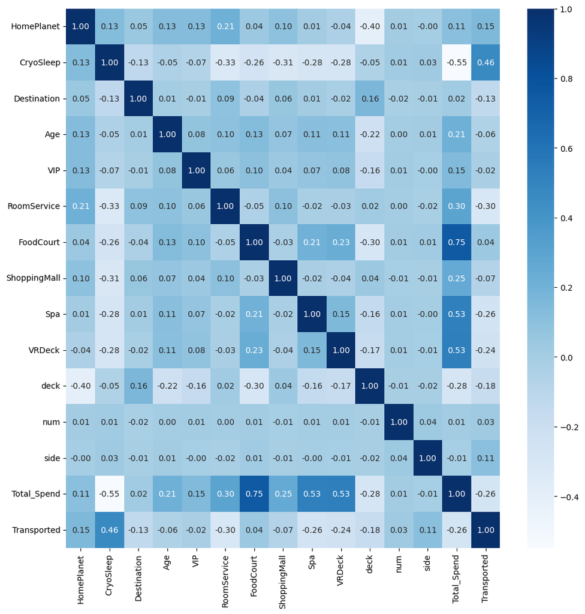

```python
plt.figure(figsize=(12, 12))
sns.heatmap(dtr_final.corr(), cmap='Blues', annot=True, fmt='.2f')
```

# Modeling

## Split Dataset

```python
X = dtr_final.drop(['Transported','Age','FoodCourt', 'ShoppingMall'], axis=1)
y = dtr_final['Transported']
```

```python
from sklearn.model_selection import train_test_split
from sklearn.preprocessing import MinMaxScaler

# Splitting Data Train - Test
X_train, X_test, y_train, y_test = train_test_split(X,
                                                    y,
                                                    test_size=0.3,
                                                    random_state=123)

print(f'Total Train Data = {X_train.shape[0]}')
print(f'Total Test Data = {X_test.shape[0]}')
```

```
Total Train Data = 5524
Total Test Data = 2368
```

```python
scaler = MinMaxScaler()

# Fitting Scaler with Train Data
scaler.fit(X_train)

# Scaling Train and Test Data
X_train_scaled = scaler.transform(X_train)
X_test_scaled = scaler.transform(X_test)
```

```python
scaler.fit(dte_final)

test_final = pd.DataFrame(scaler.transform(dte_final),index=dte_final.index,columns=dte_final.columns)
test_final = test_final.drop(['Age','FoodCourt', 'ShoppingMall'],axis=1)
```

```python
test_final.info()
```

```
<class 'pandas.core.frame.DataFrame'>
RangeIndex: 4277 entries, 0 to 4276
Data columns (total 11 columns):
 #   Column       Non-Null Count  Dtype
---  ------       --------------  -----
 0   HomePlanet   4277 non-null   float64
 1   CryoSleep    4277 non-null   float64
 2   Destination  4277 non-null   float64
 3   VIP          4277 non-null   float64
 4   RoomService  4277 non-null   float64
 5   Spa          4277 non-null   float64
 6   VRDeck       4277 non-null   float64
 7   deck         4277 non-null   float64
 8   num          4277 non-null   float64
 9   side         4277 non-null   float64
 10  Total_Spend  4277 non-null   float64
dtypes: float64(11)
memory usage: 367.7 KB
```

```python
X_train_scaled = pd.DataFrame(X_train_scaled, columns=X_train.columns)
X_test_scaled = pd.DataFrame(X_test_scaled, columns=X_test.columns)
```

```python
X_train_scaled.head()
```

|  | HomePlanet | CryoSleep | Destination | VIP | RoomService | Spa | VRDeck | deck | num | side | Total_Spend |
| --- | --- | --- | --- | --- | --- | --- | --- | --- | --- | --- | --- |
| 0 | 0.0 | 1.0 | 0.0 | 0.0 | 0.0 | 0.0 | 0.0 | 0.285714 | 0.580609 | 1.0 | 0.0 |
| 1 | 0.5 | 1.0 | 1.0 | 0.0 | 0.0 | 0.0 | 0.0 | 0.000000 | 0.511357 | 1.0 | 0.0 |
| 2 | 0.5 | 1.0 | 1.0 | 0.0 | 0.0 | 0.0 | 0.0 | 0.142857 | 0.576731 | 1.0 | 0.0 |
| 3 | 0.0 | 1.0 | 1.0 | 0.0 | 0.0 | 0.0 | 0.0 | 0.857143 | 0.892521 | 0.0 | 0.0 |
| 4 | 1.0 | 1.0 | 1.0 | 0.0 | 0.0 | 0.0 | 0.0 | 0.714286 | 0.216620 | 1.0 | 0.0 |

```python
print('X_train Shape :', X_train.shape)
print('X_test Shape :', X_test_scaled.shape)
print('X_train_scaled Shape :', X_train_scaled.shape)
print('X_test_scaled Shape :', X_test_scaled.shape)
print('y_train Shape :', y_train.shape)
print('y_test Shape :', y_test.shape)
```

```
X_train Shape : (5524, 11)
X_test Shape : (2368, 11)
X_train_scaled Shape : (5524, 11)
X_test_scaled Shape : (2368, 11)
y_train Shape : (5524,)
y_test Shape : (2368,)
```

```python
y_train.value_counts()
```

```
True     2913
False    2611
Name: Transported, dtype: int64
```

```python
from imblearn.over_sampling import SMOTE

# Random Over Sampling
sm = SMOTE(random_state=0)
sm.fit(X_train_scaled, y_train)
X_smote, y_smote = sm.fit_resample(X_train_scaled, y_train)
```

```python
y_smote.value_counts()
```

```
True     2913
False    2913
Name: Transported, dtype: int64
```

## Basic Modeling

```python
from sklearn.linear_model import LogisticRegression
from sklearn.tree import DecisionTreeClassifier
from sklearn.ensemble import RandomForestClassifier
from sklearn.ensemble import AdaBoostClassifier
from sklearn.ensemble import GradientBoostingClassifier
from xgboost import XGBClassifier

from sklearn.metrics import accuracy_score, precision_score, recall_score, f1_score, classification_report, fbeta_score
from sklearn.metrics import roc_curve, auc, roc_auc_score, confusion_matrix, make_scorer
```

```python
lr_sm = LogisticRegression()
dt_sm = DecisionTreeClassifier()
rf_sm = RandomForestClassifier()
ab_sm = AdaBoostClassifier()
gb_sm = GradientBoostingClassifier()
xg_sm = XGBClassifier()
```

```python
# Train the Model
lr_sm.fit(X_smote, y_smote)
dt_sm.fit(X_smote, y_smote)
rf_sm.fit(X_smote, y_smote)
ab_sm.fit(X_smote, y_smote)
gb_sm.fit(X_smote, y_smote)
xg_sm.fit(X_smote, y_smote)

# Predictions for the X test
y_pred_lr_sm = lr_sm.predict(X_test_scaled)
y_pred_dt_sm = dt_sm.predict(X_test_scaled)
y_pred_rf_sm = rf_sm.predict(X_test_scaled)
y_pred_ab_sm = lr_sm.predict(X_test_scaled)
y_pred_gb_sm = gb_sm.predict(X_test_scaled)
y_pred_xg_sm = xg_sm.predict(X_test_scaled)
```

```python
abcd = [['Logistic Regression', accuracy_score(y_test, y_pred_lr_sm), precision_score(y_test, y_pred_lr_sm),
          recall_score(y_test, y_pred_lr_sm), f1_score(y_test, y_pred_lr_sm), fbeta_score(y_test, y_pred_lr_sm, pos_label=0,  beta=2)],
        ['Decision Tree', accuracy_score(y_test, y_pred_dt_sm), precision_score(y_test, y_pred_dt_sm),
          recall_score(y_test, y_pred_dt_sm), f1_score(y_test, y_pred_dt_sm), fbeta_score(y_test, y_pred_dt_sm, pos_label=0, beta=2)],
        ['Random Forest', accuracy_score(y_test, y_pred_rf_sm), precision_score(y_test, y_pred_rf_sm),
          recall_score(y_test, y_pred_rf_sm), f1_score(y_test, y_pred_rf_sm), fbeta_score(y_test, y_pred_rf_sm, pos_label=0, beta=2)],
        ['Ada Boost', accuracy_score(y_test, y_pred_ab_sm), precision_score(y_test, y_pred_ab_sm),
          recall_score(y_test, y_pred_ab_sm), f1_score(y_test, y_pred_ab_sm), fbeta_score(y_test, y_pred_ab_sm, pos_label=0, beta=2)],
        ['Gradient Boost', accuracy_score(y_test, y_pred_gb_sm), precision_score(y_test, y_pred_gb_sm),
          recall_score(y_test, y_pred_gb_sm), f1_score(y_test, y_pred_gb_sm), fbeta_score(y_test, y_pred_gb_sm, pos_label=0, beta=2)],
        ['XG Boost', accuracy_score(y_test, y_pred_xg_sm), precision_score(y_test, y_pred_xg_sm),
          recall_score(y_test, y_pred_xg_sm), f1_score(y_test, y_pred_xg_sm), fbeta_score(y_test, y_pred_gb_sm, pos_label=0, beta=2)]]

df_score = pd.DataFrame(abcd,columns=['Model', 'Accuracy', 'Precision', 'Recall', 'F1 Score', 'F2 Score'],dtype=float)
df_score
```

|  | Model | Accuracy | Precision | Recall | F1 Score | F2 Score |
| --- | --- | --- | --- | --- | --- | --- |
| 0 | Logistic Regression | 0.777027 | 0.792673 | 0.773355 | 0.782895 | 0.776903 |
| 1 | Decision Tree | 0.726774 | 0.732484 | 0.747360 | 0.739847 | 0.707597 |
| 2 | Random Forest | 0.779561 | 0.817368 | 0.741673 | 0.777683 | 0.804449 |
| 3 | Ada Boost | 0.777027 | 0.792673 | 0.773355 | 0.782895 | 0.776903 |
| 4 | Gradient Boost | 0.790541 | 0.795181 | 0.804224 | 0.799677 | 0.777641 |
| 5 | XG Boost | 0.790963 | 0.808208 | 0.783916 | 0.795876 | 0.777641 |

## Hyperparameter Tuning

### Gradient Boosting

```python
from sklearn.model_selection import GridSearchCV
from sklearn.ensemble import GradientBoostingClassifier

# define model
gb = GradientBoostingClassifier()

# define parameter grid
param_grid = {
    'max_depth': [5],
    'learning_rate': [0.09999999999999998],
    'n_estimators': [92],
    'min_samples_split': [24],
    'min_samples_leaf': [1],
    'max_features': ['auto'],
    'subsample': [1]
}
#
# define GridSearchCV object
grid_search = GridSearchCV(gb, param_grid, cv=5, n_jobs=-1)

# fit model
grid_search.fit(X_smote, y_smote)

y_pred = grid_search.predict(X_test_scaled)
acc = accuracy_score(y_test, y_pred)
print('Accuracy:', acc)
```

```
Accuracy: 0.8036317567567568
```

### XG Boost

```python
model = XGBClassifier()

# Define hyperparameters for tuning
params = {
    'learning_rate' : [0.23793103448275865],
    'max_depth': [3],
    'n_estimators': [117],
    'colsample_bytree': [1],
    'subsample' :[1],
    'gamma': [0.01],
    'min_child_weight' : [3]

}

# Define GridSearchCV object
grid = GridSearchCV(estimator=model, param_grid=params, cv=2, n_jobs=-1, scoring='accuracy')

# Fit the GridSearchCV object to the data
grid.fit(X_smote, y_smote)

# Use the best model to make predictions on the test set
pred = grid.predict(X_test_scaled)

accu = accuracy_score(y_test, pred)
print('Accuracy:', accu)
```

```
Accuracy: 0.8070101351351351
```

# Submission

```python
predictions = grid.predict(test_final)
sub = pd.read_csv('../input/spaceship-titanic/sample_submission.csv')
t = pd.read_csv('../input/spaceship-titanic/test.csv')
sub['PassengerId'] = t['PassengerId']
sub['Transported'] = predictions
sub['Transported'] = sub['Transported'].astype(bool)
```

```python
sub.head()
```

|  | PassengerId | Transported |
| --- | --- | --- |
| 0 | 0013_01 | True |
| 1 | 0018_01 | False |
| 2 | 0019_01 | True |
| 3 | 0021_01 | True |
| 4 | 0023_01 | False |

```python
sub['Transported'].value_counts()
```

```
False    2200
True     2077
Name: Transported, dtype: int64
```

```python
sub.to_csv('my_submission.csv',index=False)
```

**Thank you guys, please leave your comment as I need it for my feedback :)**